# BIOST 561: Homework 3

Due date: 7:00pm on **Tuesday**, May 7th, 2024

# Note about the homework

**Note**: Most of your R code for this homework will **not** be in this homework. You mainly write `.R` files inside the `R` or `tests` folders. Therefore, you only need to show a little code inside this R Markdown file. You only need to write things inside this R Markdown file in the questions that explicitly ask you to do so.

# Q1: Designing a function to generate random graphs with partial cliques

**Question 1D**: In your homework’s R Markdown file, show that your `generate_partial_clique()` function works. Specifically, run the following lines. (If you are copy-pasting the following R chunk, remove the `eval = FALSE` tag.)

```r
library(UWBiost561)
set.seed(0)
simulation <- UWBiost561::generate_partial_clique(
  n = 10,
  clique_fraction = 0.5,
  clique_edge_density = 0.9
)

simulation$adj_mat
```

```
#>       [,1] [,2] [,3] [,4] [,5] [,6] [,7] [,8] [,9] [,10]
#>  [1,]    1    1    0    1    0    0    1    0    1     0
#>  [2,]    1    1    0    1    0    0    1    0    1     0
#>  [3,]    0    0    1    0    0    0    0    0    0     0
#>  [4,]    1    1    0    1    0    0    1    0    1     0
#>  [5,]    0    0    0    0    1    0    0    0    0     0
#>  [6,]    0    0    0    0    0    1    0    0    0     0
#>  [7,]    1    1    0    1    0    0    1    0    1     0
#>  [8,]    0    0    0    0    0    0    0    1    0     0
#>  [9,]    1    1    0    1    0    0    1    0    1     0
#> [10,]    0    0    0    0    0    0    0    0    0     1
```

# Q2: Designing a function to find the maximal partial clique

**Question 2C**: **Note that although this method would work and will find the largest partial clique, the run time of it might not be that satisfactory (it exceeds 30 secs when computing the largest partial clique for an adjancey martix of dimension 30)**

```r
library(UWBiost561)
set.seed(0)
simulation <- UWBiost561::generate_partial_clique(
  n = 10,
  clique_fraction = 0.5,
  clique_edge_density = 0.9
)

adj_mat <- simulation$adj_mat

res <- UWBiost561::compute_maximal_partial_clique(
  adj_mat = adj_mat,
  alpha = 0.9
)
res
```

```
#> $clique_idx
#> [1] 1 2 4 7 9
#>
#> $edge_density
#> [1] 1
```

# Q3: Developing unit tests for your functions

**Intent**: The intent of this question is to give you experience writing unit tests inside your `UWBiost561` package.

**Question 3A**: Following the overview in Lecture 5, as well as additional walkthrough in https://docs.google.com/document/d/103ayPYvyzXHa84YFt-cQm_hMM1Ukqo7hlUygYD6UnC0/edit?usp=sharing, create a `tests` folder in your `UWBiost561` package that contains a `testthat.R` file (shown below) as well as `testthat` folder. (There is nothing to report for this question.)

```r
# This is what your testthat.R file should contain
library(testthat)
library(UWBiost561)

testthat::test_check("UWBiost561")
```

**Question 3B**: Write at least two unit tests for your `generate_partial_clique()` function inside a file called `test_generate_partial_clique.R` within the `testthat` folder. (There is nothing to report for this question. Your code will be in the `tests/testthat` folder, **not** in this R Markdown file.)

**Question 3C**: Writing at least five unit tests for your `compute_maximal_partial_clique()` function inside a file called `test_compute_maximal_partial_clique.R` within the `testthat` folder. Based on the “List of types of unit-tests” page in Lecture 5, ensure each of the five unit tests is in a “different category.” (There is nothing to report for this question. Your code will be in the `tests/testthat` folder, **not** in this R Markdown file.)

Some pointers:

- You should use `generate_partial_clique()` within some of your tests for `compute_maximal_partial_clique()`. Since **you** are constructing the random adjacency matrix with a partial clique with at least edge density of `clique_edge_density` of size `round(n*clique_fraction)`, then you should expect that for “simple” random adjacency matrices, your `compute_maximal_partial_clique()` can recover the partial clique that **you** constructed.

**Question 3D**: Run `devtools::test()` for your R package `UWBiost561` when you’re in your R project. (There is nothing to report for this question. Your code will be in the R console, **not** in this R Markdown file.)

# Q4: Finalizing your R package

**Intent**: The intent of this question is to experience the basics of making an R package.

**Question 4A**: Fix the `DESCRIPTION` file as needed. Importantly, this involves adding any R package dependencies your `generate_partial_clique()` and `compute_maximal_partial_clique()` depend on. (If none, you don’t need to worry about this.) You should also replace the default author, package title, and description with something more meaningful. (There is nothing to report for this question.)

**Question 4B**: In your R project for the `UWBiost561` package, run the command `usethis::use_mit_license()` in the R console. (There is nothing to report for this question.)

At this point, your R package should have the following.

- `R` folder:
  - File specifically called `generate_partial_clique.R`
  - File specifically called `compute_maximal_partial_clique.R`
- `tests` folder:
  - File specifically called `testthat.R`
  - `testthat` folder:
    - File specifically called `test_generate_partial_clique.R`
    - File specifically called `test_compute_maximal_partial_clique.R`
- `vignettes` folder:
  - Multiple files, including files such as `HW1.Rmd`, `HW1.html`, `HW2.Rmd`, `HW2.html`, `HW3.Rmd`, `HW3.html` (or analogously named)
- File specifically called `DESCRIPTION`
- File specifically called `LICENSE`
- File specifically called `.Rbuildignore`
- (And other potential files)

**Question 4B**: Run `devtools::check()`. Ensure there are no errors, but it’s okay if you don’t want to fix the warnings. (`devtools::check()` will also automatically generate a `man` folder with your documentation converted from your ROxygen code and a `NAMESPACE` file.) It might take a while to fix all the errors that `devtools::check()` complains about – I would advise using Google to determine what exactly it is unhappy about, or you can ask on the Canvas Discussion board. (There is nothing to report for this question. Your code will be in the R console, **not** in this R Markdown file.)

**Question 4C**:

Figure 1 and 2 shows the screenshots you are trying to reproduce.

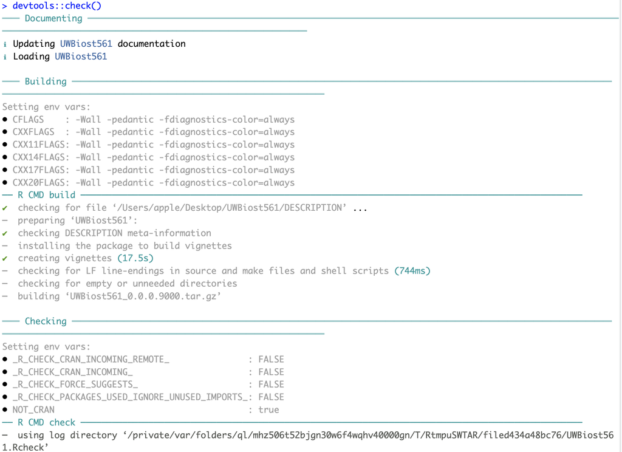

Figure 1: The first screenshot you are trying to reproduce (without the Sample watermark) in Question 4C.

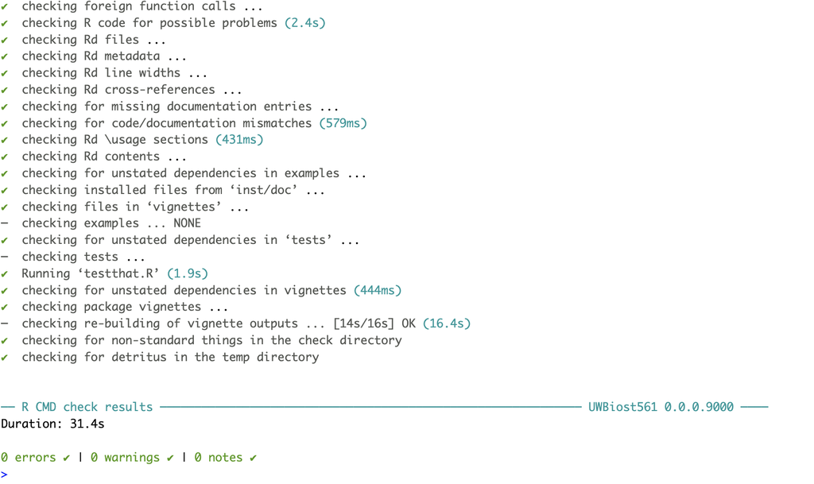

Figure 2: The second screenshot you are trying to reproduce (without the Sample watermark) in Question 4C.

# Q5: Storyline for HW4 and final project

**Question 5A**: “I can access OpenSesame.”

**Question 5B**: In a few sentences, please describe what you think you’d like to make do for your final project:

I am thinking about combine the project for BIOST527 (probably related to the constrained density estimation), with this course project, that is to create a R package people to implement this constrained density estimation method.